# Assignment 3

## Step 3: Add Data Visualizations

We will start creating visualizations for precincts using different statistical concepts such as mean, median, variance, and standard deviation.

```r
stats_p_monthly <- aggregate(INCIDENTS ~ PRECINCT, p_monthly_incidents,
                             function(x) c(M = mean(x), SD = sd(x), VAR = var(x)))
summary(stats_p_monthly)
```

```
##     PRECINCT          INCIDENTS.M         INCIDENTS.SD         INCIDENTS.VAR
##  Min.   :  1.00   Min.   :1.000000     Min.   :0.447214     Min.   : 0.200000
##  1st Qu.: 32.00   1st Qu.:1.629032     1st Qu.:1.044277     1st Qu.: 1.090935
##  Median : 66.00   Median :2.018018     Median :1.522301     Median : 2.317490
##  Mean   : 63.32   Mean   :2.597242     Mean   :1.841815     Mean   : 4.465072
##  3rd Qu.:100.00   3rd Qu.:3.195531     3rd Qu.:2.406016     3rd Qu.: 5.789859
##  Max.   :123.00   Max.   :7.632353     Max.   :5.583855     Max.   :31.179441
##                   NA                   NA's   :1            NA's   :1
```

```r
mean(p_monthly_incidents$INCIDENTS)
```

```
## [1] 3.277178
```

```r
sd(p_monthly_incidents$INCIDENTS)
```

```
## [1] 2.981839
```

```r
var(p_monthly_incidents$INCIDENTS)
```

```
## [1] 8.891362
```

```r
stats_p_yearly <- aggregate(INCIDENTS ~ PRECINCT, p_yearly_incidents,
                            function(x) c(M = mean(x), SD = sd(x), VAR = var(x)))
summary(stats_p_yearly)
```

```
##     PRECINCT          INCIDENTS.M         INCIDENTS.SD         INCIDENTS.VAR
##  Min.   :  1.00   Min.   : 1.00000     Min.   : 0.752773    Min.   :  0.5667
##  1st Qu.: 32.00   1st Qu.: 5.05882     1st Qu.: 3.396687    1st Qu.: 11.5727
##  Median : 66.00   Median :12.35294     Median : 5.733492    Median : 32.8897
##  Mean   : 63.32   Mean   :21.12328     Mean   : 8.168798    Mean   :106.2455
##  3rd Qu.:100.00   3rd Qu.:29.41176     3rd Qu.:11.813479    3rd Qu.:139.5588
##  Max.   :123.00   Max.   :91.58824     Max.   :29.742770    Max.   :884.6324
##                   NA                   NA's   :1            NA's   :1
```

```r
mean(p_yearly_incidents$INCIDENTS)
```

```
## [1] 22.72213
```

```r
sd(p_yearly_incidents$INCIDENTS)
```

```
## [1] 23.3518
```

```r
var(p_yearly_incidents$INCIDENTS)
```

```
## [1] 545.3066
```

All the incidents vary according to the precinct. The data reflects the monthly and the magnitude of numbers is larger, it’s easier to see the variation. We might get a similar result from Boro.

```r
stats_b_monthly <- aggregate(INCIDENTS ~ BORO, b_monthly_incidents,
                             function(x) c(M = mean(x), SD = sd(x), VAR = var(x)))
summary(stats_b_monthly)
```

```
##      BORO
##  Length:5
##  Class :character
##  Mode  :character
##
##
##
##      INCIDENTS.M         INCIDENTS.SD         INCIDENTS.VAR
##  Min.   : 3.95918     Min.   : 2.575699    Min.   :  6.6342
##  1st Qu.:17.50980     1st Qu.: 8.558975    1st Qu.: 73.2561
##  Median :20.06863     Median : 9.123412    Median : 83.2366
##  Mean   :26.80752     Mean   :12.423263    Mean   :214.3204
##  3rd Qu.:38.90686     3rd Qu.:16.902973    3rd Qu.:285.7105
##  Max.   :53.59314     Max.   :24.955254    Max.   :622.7647
```

```r
mean(b_monthly_incidents$INCIDENTS)
```

```
## [1] 26.98814
```

```r
sd(b_monthly_incidents$INCIDENTS)
```

```
## [1] 22.74222
```

```r
var(b_monthly_incidents$INCIDENTS)
```

```
## [1] 517.2086
```

```r
stats_b_yearly <- aggregate(INCIDENTS ~ BORO, b_yearly_incidents,
                            function(x) c(M = mean(x), SD = sd(x), VAR = var(x)))
summary(stats_b_yearly)
```

```
##      BORO
##  Length:5
##  Class :character
##  Mode  :character
##
##
##
##      INCIDENTS.M         INCIDENTS.SD         INCIDENTS.VAR
##  Min.   : 45.6471     Min.   : 10.71180    Min.   :  114.743
##  1st Qu.:210.1176     1st Qu.: 59.49605    1st Qu.: 3539.779
##  Median :240.8235     Median : 70.13102    Median : 4918.360
##  Mean   :321.3176     Mean   : 86.49129    Mean   :10531.721
##  3rd Qu.:466.8824     3rd Qu.:119.41884    3rd Qu.:14260.860
##  Max.   :643.1176     Max.   :172.69876    Max.   :29824.860
```

```r
mean(b_yearly_incidents$INCIDENTS)
```

```
## [1] 321.3176
```

```r
sd(b_yearly_incidents$INCIDENTS)
```

```
## [1] 233.3874
```

```r
var(b_yearly_incidents$INCIDENTS)
```

```
## [1] 54469.7
```

## Visualization 1:

A few questions that we need to analyze through the visualiations are Question: Which part of NY has more number of incidents?**

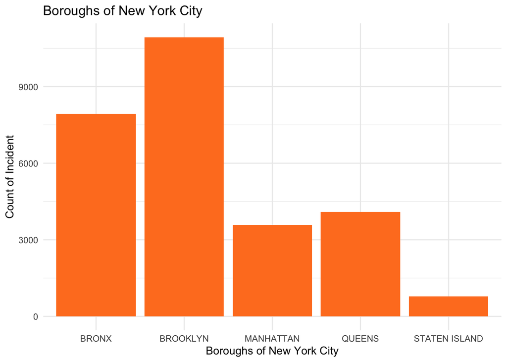

```r
g <- ggplot(csv_data, aes(x = BORO)) +
  geom_bar(fill="#FF7F24") +
  labs(title = "Boroughs of New York City",
       x = "Boroughs of New York City",
       y = "Count of Incident") +
  theme_minimal()
g
```

```r
table(csv_data$BORO, csv_data$STATISTICAL_MURDER_FLAG)
```

```
##
##                 FALSE TRUE
##   BRONX          6395 1542
##   BROOKLYN       8811 2122
##   MANHATTAN      2942  630
##   QUEENS         3284  810
##   STATEN ISLAND   614  162
```

Looking at the above visualization, it seems that Brooklyn is the highest in terms of maximum incidents followed by Bronx, Queens, Manhattan, and Staten Island. Staten Island is the region with the lowest number of incidents according to the data.